# lab03 Checkpoint 3

## 2.Dados

Os dados em questão aqui são dados disponibilizados pela CAPES, utilizados na avaliação de cursos de pós-graduação das universidades brasileiras.

Vamos carregar e observar o dataset disponibilizado:

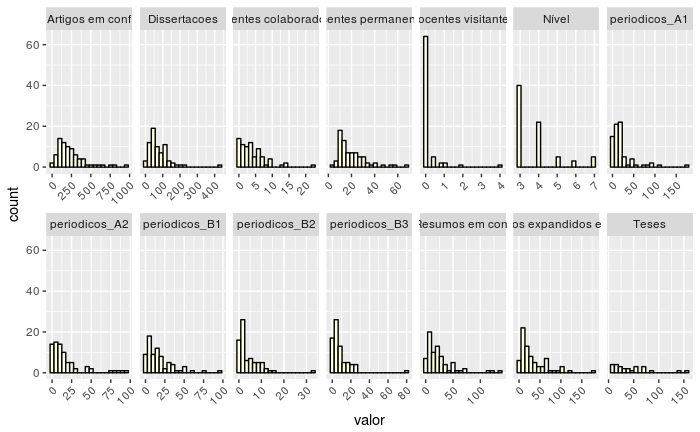

```r
capes = read_csv("dados//capes-cacc.csv")
capes[0:18] %>% gather(key = "variavel", value = "valor", -Sigla, -`Tem doutorado`, -Instituição, -Programa) %>%
    ggplot(aes(x = valor)) +
    theme(axis.text.x = element_text(angle = 45, hjust = 1)) +
    geom_histogram(fill = "lightyellow", color = "black", bins = 20) +
    facet_wrap(~ variavel, scales = "free_x", ncol=7)
```

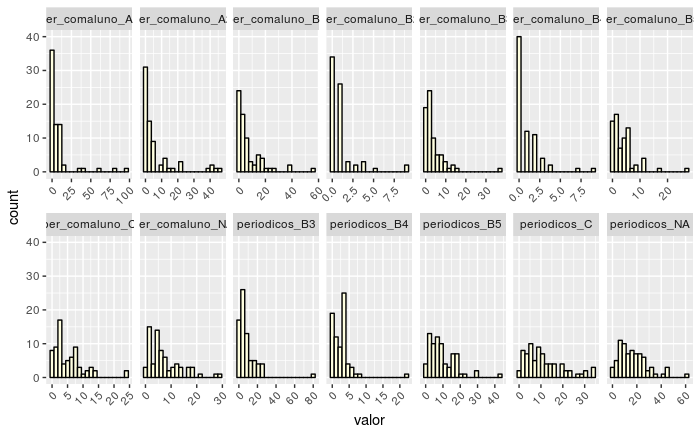

```r
capes[18:31] %>% gather(key = "variavel", value = "valor") %>%
    ggplot(aes(x = valor)) +
    theme(axis.text.x = element_text(angle = 45, hjust = 1)) +
    geom_histogram(fill = "lightyellow", color = "black", bins = 20) +
    facet_wrap(~ variavel, scales = "free_x", ncol=7)
```

```r
capes$Teses[is.na(capes$Teses)] = 0
capes$Dissertacoes[is.na(capes$Dissertacoes)] = 0
filtered_capes =  capes %>% mutate(docentes=`Docentes permanentes`+`Docentes colaboradores`+`Docentes visitantes`, trabalhos_produzidos=Teses+Dissertacoes) %>%
  select(Sigla, Programa, `Nível`, docentes, `Artigos em conf`, trabalhos_produzidos, periodicos_A1)
scaled_capes = filtered_capes %>% mutate_at(vars(`Nível`:periodicos_A1), funs(as.numeric(scale(.))))
```

Temos acima os histogramas das variáveis presentes no dataset disponibilzado. Podemos perceber alguns padrões de grupos em algumas delas. Mas nada que, a priori, chame muito a atenção. Todas parecem ter maior concentração à esquerda, com uma calda relativamente longa, padrão bastante comum para esse tipo de dado.

Analisando as variáveis, escolhemos para o agrupamento, as seguintes:

- docentes ( docentes_colaboradores + docentes permanentes + docentes visitantes). Condensamos aqui três variáveis presentes no dataset em apenas uma.
- trabalhos_produzidos ( teses + dissertações). Dessa vez, condesamos duas variáveis. Consideraremos o total de trabalhos produzidos pelo programa, ao invés de fragmentá-lo por curso.
- Nível
- Artigos em conferencia
- periodicos_A1

Visualizando a relação entre as variáveis agora:

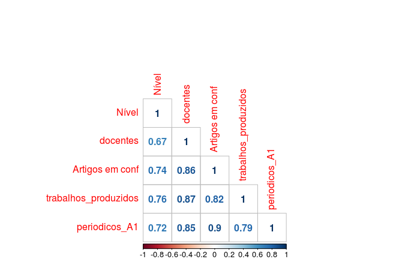

```r
cor(filtered_capes %>% select(-Programa, -Sigla)) %>% corrplot(method = "number", type = "lower")
```

Podemos perceber uma forte correlação entre as variáveis, sendo a menor delas entre o número de docentes e o nível do programa de 0.67, entre docentes e Nível, que apesar de ser a mais baixa encontrada, ainda pode ser considerada alta.

## 3.Agrupamento

Uma vez escolhida as variáveis para o agrupamento, partimos para tal:

Primeiramente vamos estimar um número K de grupos para o K-means

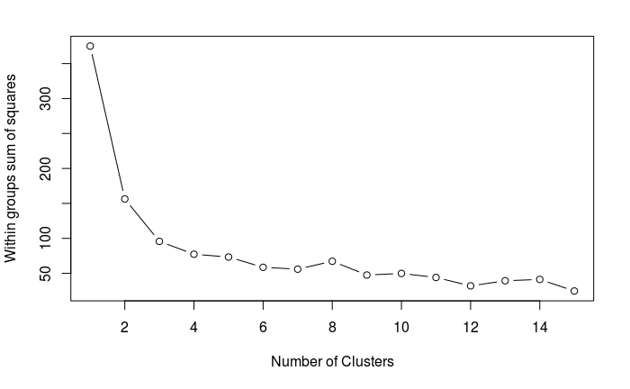

```r
# Determine number of clusters
wss <- (nrow(scaled_capes[3:7]))*sum(apply(scaled_capes[3:7],2,var))
for (i in 2:15) wss[i] <- sum(kmeans(scaled_capes[3:7],
    centers=i)$withinss)
plot(1:15, wss, type="b", xlab="Number of Clusters",
  ylab="Within groups sum of squares")
```

Observando o gráfico acima, percebemos que a partir de 3 clusters a diferença não é tão grande quanto a diferença de 1 para 2 e de 2 para 3. Logo, escolheremos K=3 para nossa análise. É importante salientar aqui que os dados foram normalizados para o agrupamento, evitando assim que uma variável tenha um peso signficativamente maior que outra de maneira indevida.

```r
k_means_result <- kmeans(scaled_capes[3:7], centers = 3, nstart = 20)
aggregate(scaled_capes[3:7],by=list(k_means_result$cluster),FUN=median)
```

| Group.1 | Nível | docentes | Artigos em conf | trabalhos_produzidos | periodicos_A1 |
| --- | --- | --- | --- | --- | --- |
| 1 | -0.7018113 | -0.4440123 | -0.4850960 | -0.4370310 | -0.4722373 |
| 2 | 0.5925128 | 0.5748705 | 0.5925726 | 0.5796216 | 0.1390166 |
| 3 | 2.7497198 | 2.2904252 | 2.8486010 | 1.9296028 | 2.4967100 |

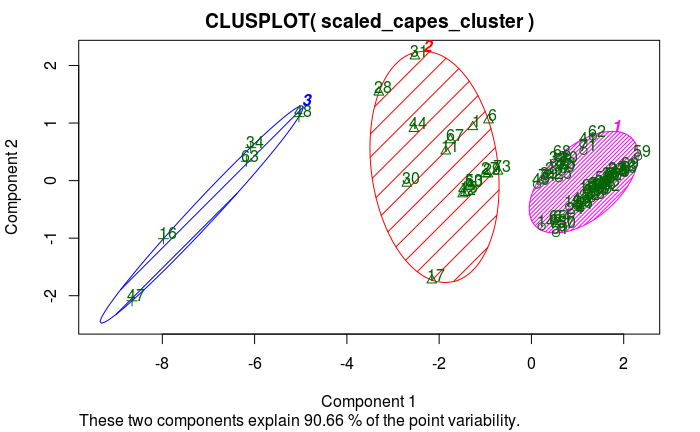

```r
scaled_capes_cluster <- data.frame(scaled_capes[3:7], k_means_result$cluster)
clusplot(scaled_capes_cluster, k_means_result$cluster, color=TRUE, shade=TRUE,
    labels=2, lines=0)
```

```r
scaled_capes_cluster$.row <- rownames(scaled_capes_cluster)
  teste <- melt(scaled_capes_cluster, id = c(".row", "k_means_result.cluster") )
parallel_plot = ggplot(teste, aes(x = variable, y = value, group = .row, colour = k_means_result.cluster)) +
    theme(axis.text.x = element_text(angle = 45, hjust = 0)) +
    geom_line(alpha = .2) +
    facet_wrap(~ k_means_result.cluster)
ggplotly(parallel_plot)
```

```
We recommend that you use the dev version of ggplot2 with `ggplotly()`
Install it with: `devtools::install_github('hadley/ggplot2')`
```

[interactive chart not shown]

Uma vez executado o agrupamento para um k=3, percebemos a presença de grupos que, intuitivamente, fazem sentido. Podemos classificar informalmente os grupos como:

1. Programas de nível baixo
2. Programas de nível médio
3. Programas de nivel alto

Mais especificamente, para o primeiro grupo, observamos em geral: Nível baixo, baixo número médio de docentes, baixo número de artigos em conferências como também de trabalhos produzidos e publicos em eventos classificados como A1 pela CAPES. Esse é o grupo com maior número de programas.

Já o terceiro grupo apresenta alguns poucos programas de pós-graduação. Percebemos que eles variam entre si, mas possuem valores consideravelmente altos para todas as variáveis.

## 4.Redução de Dimensionalidade

Dado que em nosso agrupamento consideramos 5 variáveis, precisamos de uma maneira legal de visualizar isso, uma vez que temos uma limitação que não nos permite visualizar as 5 facilmente. Para isso, faremos uso de redução de dimensionalidade.

Para tal, utilizaremos a técnica PCA(principal component analysis) de modo que possamos vizualizar, em um plano 2D, a influência das variáveis.

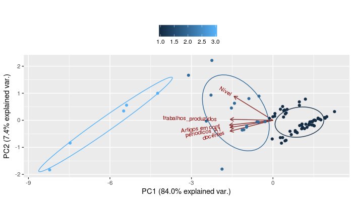

```r
pca_data <- prcomp(scaled_capes[3:7],center = TRUE)
scaled_capes <- data.frame(scaled_capes[3:7], k_means_result$cluster)
ppg.groups = scaled_capes[, 6]
pca_plot <- ggbiplot(pca_data, obs.scale = 1, var.scale = 1,
              groups = ppg.groups, ellipse = TRUE,
              circle = FALSE) +
  scale_color_continuous(name = '') +
  theme(legend.direction = 'horizontal',
               legend.position = 'top')
print(pca_plot)
```

O resultado nos motra, circulado por elipses e de cores diferentes, os grupos classificados. Percebemos aqui uma coerência dos grupos formados, dado o posicionamento dos pontos, mesmo reduzindo para duas dimensões. Analisando o resultado, podemos validar, como visto anteriormente, a alta correlação entre as variáveis escolhidas no agrupamento. Percebemos também que o componente 1 representa em 84% os nossos dados, valor bem alto. Isso pode ter sido alcançado justamente pelo quase alinhamento de 4 das variáveis com o eixo X, como também pela alta correlação entre as variáveis.

Das variáveis, a que mais difere da direção das demais é a variável Nível, que, provavelmente, garante boa parte dos 7.4% explicado pelo PC2.